# Workshop Konsumentenpreise

Nima Riahi

2023-11-30

# Workshop Session: Exploration Landesindex Konsumentenpreise

Wir untersuchen den vom BfS veröffentlichten Landesindex Konsumentenpreise (Teuerungsdaten :-). Wie sehr sind die Kosten für Konsumenten in der Schweiz gestiegen? Wie verechnet sich der Gesamtindex? Wie setzt er sich zusammen?

Die Daten ([lik-bfs](https://www.bfs.admin.ch/bfs/de/home/statistiken/preise/landesindex-konsumentenpreise/detailresultate.assetdetail.29065700.html)) stehen als Excel Datei bereit. Wir beschränkten uns primär auf den Reiter `INDEX_m`, der die Indexdaten enthält. Der Index wird relativ granular für verschiedene Konsumsegmente berechnet wie z.B. Frühstückscerealien, Wohnmöbel, Getränke im Restaurant, Belletristik-Bücher. Diese granularen Levels werden dann aggregiert auf grössere Segmente (z.B. Bekleidung, Verkehr, Restaurant und Hotels, etc.). Diese Granularitätsstufen werden mit dem `Level` (ein Integer) identifiziert.

Im letzten Abschnitt betrachten wir auch die Preisänderungen, die im Reiter `VAR_m-1` enthalten sind.

# Beschreibung des Datensatzes

```
## [1] "Datumsbereich der Daten: 1982-12-01 bis 2024-10-01"
```

```
## [1] "Aufteilung der Index-Tiefen, exemplarisch für Oktober 2023:"
```

```
## Level
##   1   2   3   4   5   6   7   8
##   1  12  41 101 139  89  28   5
```

Eine detaillierte Betrachtung wird direkt im Excel gemacht.

# Gesamtüberblick über die Hauptkategorien des LIK

Wir visualisieren als erstes den Gesamtindex (`Level==1`).

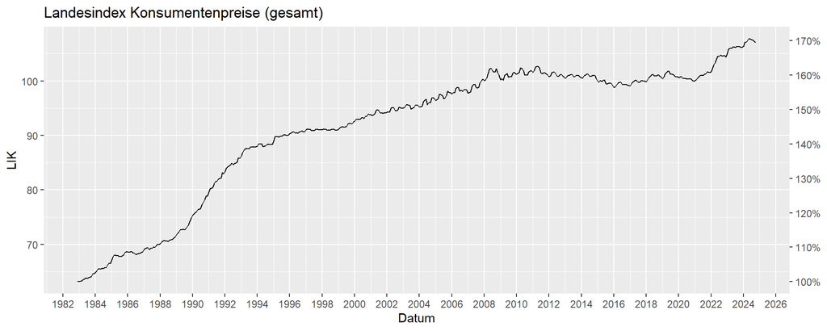

```r
dat_proc_p <- dat_proc %>% filter(Level==1)
ggplot(dat_proc_p, aes(x=Datum, y=LIK)) +
  geom_line(color="black") +
  scale_x_date(date_breaks = "2 years", date_labels = "%Y") +
  scale_y_continuous(
    sec.axis = sec_axis(
      trans = function(x) {100*x/min(dat_proc_p$LIK)},
      breaks = seq(100,170,10), labels = sprintf("%.0f%%",seq(100,170,10))
      )
  ) +
  labs(title="Landesindex Konsumentenpreise (gesamt)")
```

Was können wir beobachten?

- Verhalten der Steigung
- Variabilität der Kurve
- Effektive Teuerung?

Die folgende Darstellung zeigt die Indizes der Hauptkategorien, aus denen sich der Gesamtindex zusammensetzt (`Level == 2`):

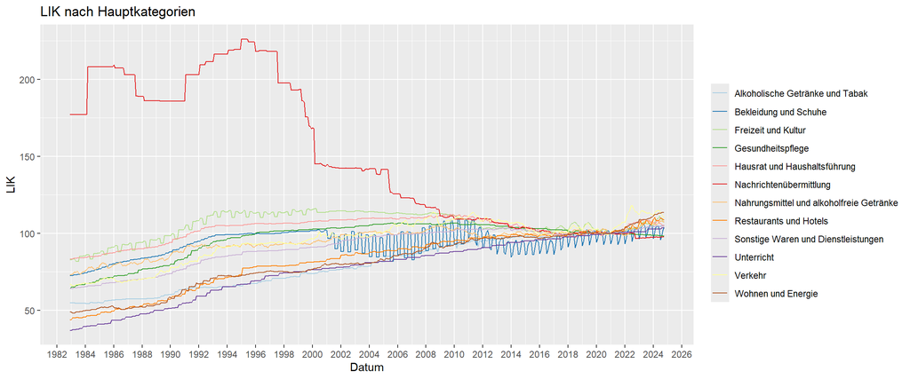

```r
dat_proc_p <- dat_proc %>% filter(Level == 2)
ggplot(dat_proc_p, aes(x=Datum, y=LIK, color=Position_D)) +
  geom_line() +
  scale_color_manual(values = col_brewer) +
  labs(colour="", title="LIK nach Hauptkategorien") +
  scale_x_date(date_breaks = "2 years", date_labels = "%Y")
```

Diskussion:

- Sind die Indizes der Hauptkategorien vergleichbar?
- Was geschah mit dem Segment “Bekleidung und Schuhe” ab 2000?
- Wie ist die Situation ab 2020 (Corona) zu beschreiben im Kontext der letzten 40 Jahre?

Beschränkung auf 2019 bis heute:

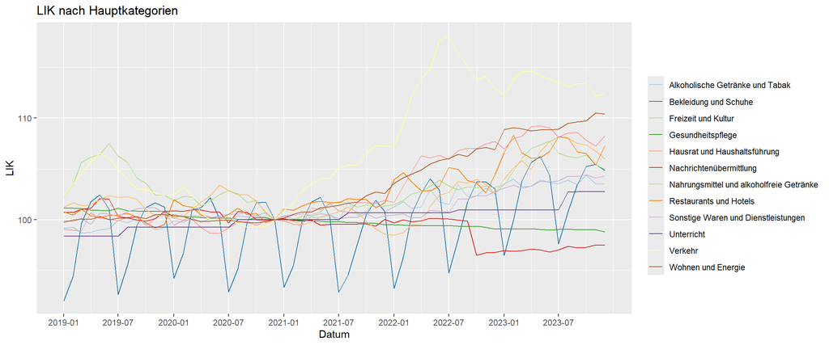

```r
dat_proc_p <- dat_proc %>% filter(Level==2) %>% filter(Datum>="2019-01-01")
# dat_proc_p <- dat_proc %>% filter(Pos)
ggplot(dat_proc_p, aes(x=Datum, y=LIK, color=Position_D)) +
  geom_line() +
  scale_color_manual(values = col_brewer) +
  scale_x_date(
    breaks = seq.Date(as.Date("2019-01-01"), as.Date("2023-11-01"), by = "6 months"),
    date_labels = "%Y-%m",
    limits = as.Date(c("2019-01-01", "2023-12-01"))
    ) +
  labs(colour="", title="LIK nach Hauptkategorien")
```

## Verkehr

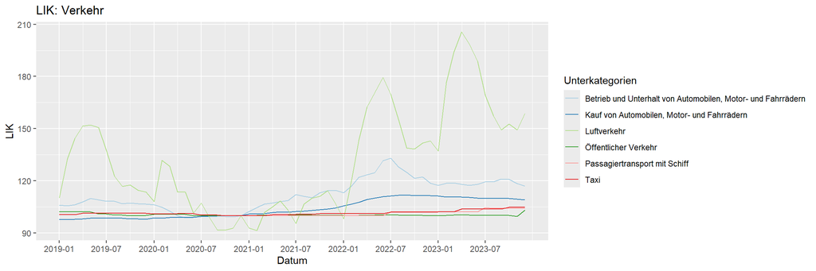

```r
dat_proc_p <- dat_proc %>%
  filter(Datum>="2019-01-01") %>%
  filter(PosNo>=7000 & PosNo<8000) %>% filter(Level==4)

ggplot(dat_proc_p, aes(x=Datum, y=LIK, color=Position_D)) +
  geom_line() +
  scale_color_manual(values = col_brewer) +
  scale_x_date(
    breaks = seq.Date(as.Date("2019-01-01"), as.Date("2023-11-01"), by = "6 months"),
    date_labels = "%Y-%m",
    limits = as.Date(c("2019-01-01", "2023-12-01"))
    ) +
  labs(colour="Unterkategorien", title="LIK: Verkehr")
```

Diskussion:

- Welche Rolle spielte der öffentliche Verkehr für die Teuerung?
- Was hat es mit den Preis *Bumps* im Luftverkehr auf sich?
- Wie würden Sie Flugverkehr, ÖV und Taxi gewichten für die Berechnung des Index “Verkehr”?

## Wohnen und Energie

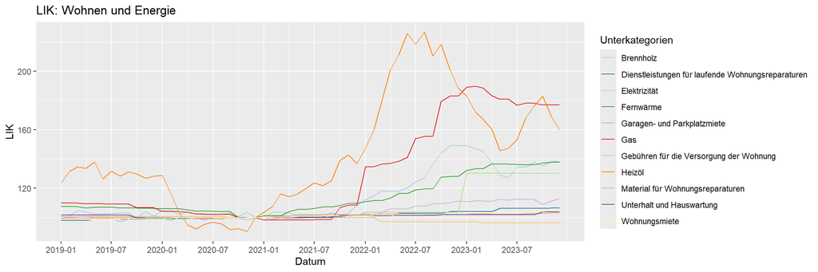

```r
dat_proc_p <- dat_proc %>%
  filter(Datum>="2019-01-01") %>%
  filter(PosNo>=4000 & PosNo<5000) %>% filter(Level==4)

ggplot(dat_proc_p, aes(x=Datum, y=LIK, color=Position_D)) +
  geom_line() +
  scale_color_manual(values = col_brewer) +
  scale_x_date(
    breaks = seq.Date(as.Date("2019-01-01"), as.Date("2023-11-01"), by = "6 months"),
    date_labels = "%Y-%m",
    limits = as.Date(c("2019-01-01", "2023-12-01"))
    ) +
  labs(colour="Unterkategorien", title="LIK: Wohnen und Energie")
```

Diskussion:

- Was treibt die Teuerung primär an?
- Wie ist die Bezeichnung der Hauptkategorie des Index zu beurteilen für diese Analyseperiode?

## Kleidung

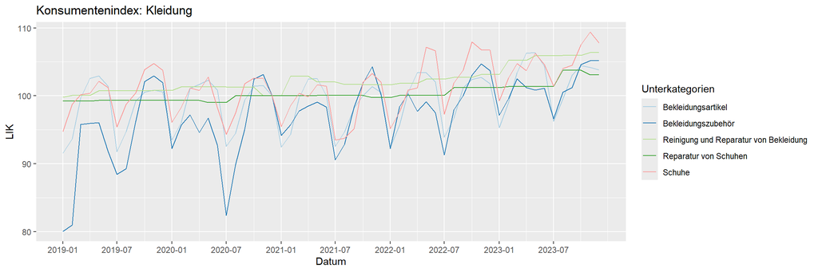

```r
dat_proc_p <- dat_proc %>%
  filter(Datum>="2019-01-01") %>%
  filter(PosNo>=3000 & PosNo<4000) %>% filter(Level==4)

ggplot(dat_proc_p, aes(x=Datum, y=LIK, color=Position_D)) +
  geom_line() +
  scale_color_manual(values = col_brewer) +
  scale_x_date(
    breaks = seq.Date(as.Date("2019-01-01"), as.Date("2023-11-01"), by = "6 months"),
    date_labels = "%Y-%m", limits = as.Date(c("2019-01-01", "2023-12-01"))) +
  labs(colour="Unterkategorien") +
  ggtitle("Konsumentenindex: Kleidung")
```

Diskussion:

- Wir würden Sie die deutlich erkennbaren “Wellenlinien” charakterisieren?
- Was könnte die Ursache dafür sein?

## Restaurants und Hotels

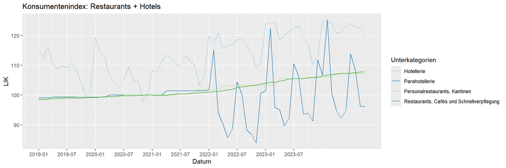

```r
dat_proc_p <- dat_proc %>%
  filter(Datum>="2019-01-01") %>%
  filter(PosNo>=11000 & PosNo<12000) %>% filter(Level==4)

ggplot(dat_proc_p, aes(x=Datum, y=LIK, color=Position_D)) +
  geom_line() +
  scale_color_manual(values = col_brewer) +
  scale_x_date(
    breaks = seq.Date(as.Date("2019-01-01"), as.Date("2023-11-01"), by = "6 months"),
    date_labels = "%Y-%m") +
  labs(colour="Unterkategorien") +
  ggtitle("Konsumentenindex: Restaurants + Hotels")
```

## Preisänderungen

Wir betrachten im Folgenden die prozentualen Preisänderungen auf den jeweiligen Vormonat.

Nachfolgend die Visualisierung der monatlichen prozentualen Änderungen für die 12 Hauptkategorien des Landesindex:

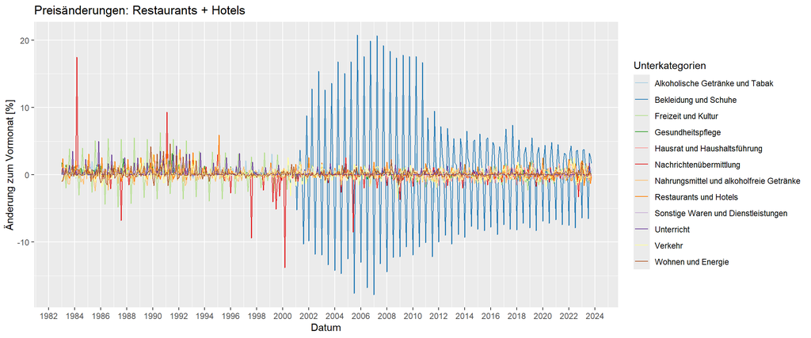

```r
dat_proc_p <- dat_proc %>% filter(Level==2)

ggplot(dat_proc_p, aes(x=Datum, y=preis_var, color=Position_D)) +
  geom_line() +
  scale_color_manual(values = col_brewer) +
  scale_x_date(date_breaks = "2 years", date_labels = "%Y") +
  labs(colour="Unterkategorien", y="Änderung zum Vormonat [%]") +
  ggtitle("Preisänderungen: Restaurants + Hotels")
```

Die stark saisonale Komponente des Warenkorbteils “Bekleidung und Schuhe” ist in dieser Darstellung noch deutlicher erkennbar.

Hier die monatlichen prozentualen Änderungen des Gesamtindex:

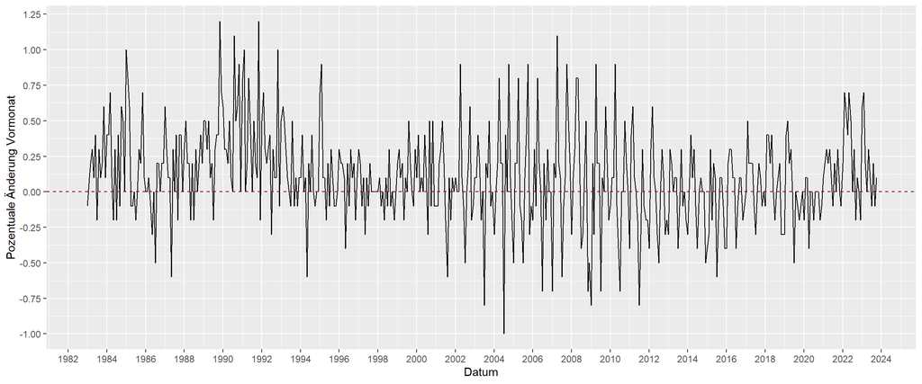

```r
dat_proc_p <- dat_proc %>% filter(Level==1)
ggplot(dat_proc_p, aes(x=Datum, y=preis_var)) +
  geom_line() +
  scale_x_date(
    date_breaks = "2 years",
    date_labels = "%Y") +
  scale_y_continuous(
    breaks = seq(-1.5,1.5,.25),
    name = "Pozentuale Änderung Vormonat"
    ) +
  geom_hline(yintercept = 0, color="darkred", linetype = "dashed")
```

Können wir den Gesamtindex reproduzieren basierend auf die monatlichen Änderungsraten? Dazu führen wir eine kumulative Multiplikation der monatlichen Änderungsraten durch.

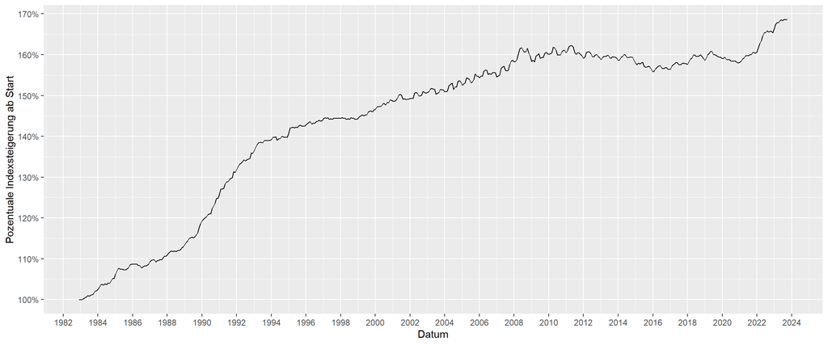

```r
# Prozentuale Änderungen
v <- dat_proc_p$preis_var
# Multiplikativer Faktor der Änderung
v <- v/100 + 1
# Der erste Zeitstempel erhält den Wert 1
v[1] <- 1
# Kumulative Multiplikation
v <- cumprod(v)


dat_proc_p$preis_var_cum <- v
ggplot(dat_proc_p, aes(x=Datum, y=preis_var_cum)) +
  geom_line() +
  scale_x_date(
    date_breaks = "2 years",
    date_labels = "%Y") +
  scale_y_continuous(
    breaks = seq(1,1.7,.1),
    labels = sprintf("%.0f%%", 100*seq(1,1.7,.1)),
    name = "Pozentuale Indexsteigerung ab Start"
    )
```